# QC process guidelines

Jing Gu

01/31/2020

### Quality Control Procedures following guidlines from the bioRxive paper (see link below)

#### https://www.biorxiv.org/content/10.1101/416545v1

### GWAS QC steps for base and target data:

### QC checklist: Base data

##### Heritability check:

Base data needs to have chip-heritability estimate $h^2_{snp}$ > 0.05 Use LDSC to estimate chip-heritability

#### Effect allele:

The effect alleles from the base GWAS data need to be known.

#### File transfer|genome build

### Standard GWAS QC:

- remove SNPs with MAF < 1% and INFO < 0.8
- remove ambiguous SNPs

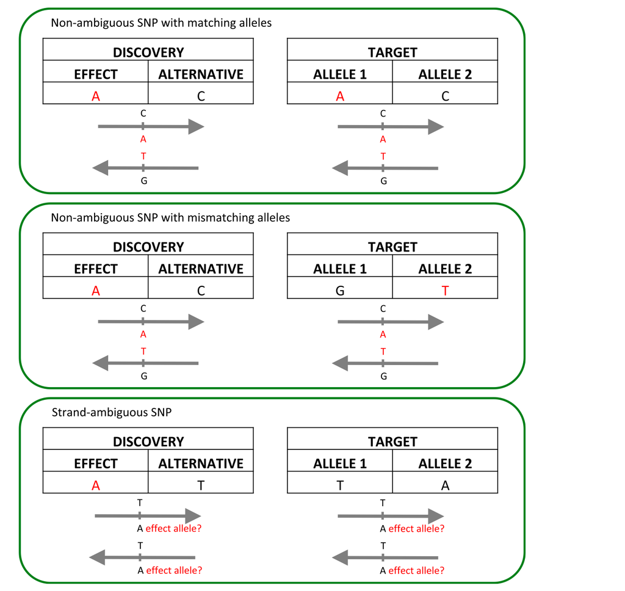

- remove duplicate SNPs
- check for sex mislabeling, sample overlap, individual relatedness

#### Sample Size, file transfer, genome build

### Standard GWAS QC (ref: Marees et al.)

- Remove SNPs with $\rm MAF < 0.05, \text HWE(p.value) < 10^{-6}, GENO > 0.01, \rm mind >0.01$
- Remove samples with extreme heterzygosity
  - DNA contamination
  - High levels of inbreeding
- Mismatching genotypes
  - Flip the alleles to match with those in the base data
- check for sex mislabeling, sample overlap, individual relatedness

### Plink C+T Approach

- Parameters:
- LD $r^2$ threshold set to be 0.1.
- Window size for clumping: 250k

### PRSice-2 C+T Approach

- Parameters:
- covariate file for target data (FID, IID, sex, PCs)
- –prsice PRSice_linux  
  –base Height.QC.gz  
  –target EUR  
  –keep EUR.QC.rel.id  
  –extract EUR.QC.snplist  
  –binary-target F  
  –pheno EUR.height  
  –cov EUR.cov  
  –base-maf MAF,0.01  
  –base-info INFO,0.8  
  –out EUR

PRSice-2

```r
covariate<-read.table("./EUR.covariate", header = T)
pcs<-read.table("./EUR.eigenvec", header = F)
colnames(pcs) <- c("FID","IID", paste0("PC",1:6))
cov <- merge(covariate, pcs, by=c("FID", "IID"))
write.table(cov,"EUR.cov", quote=F, row.names=F)
```

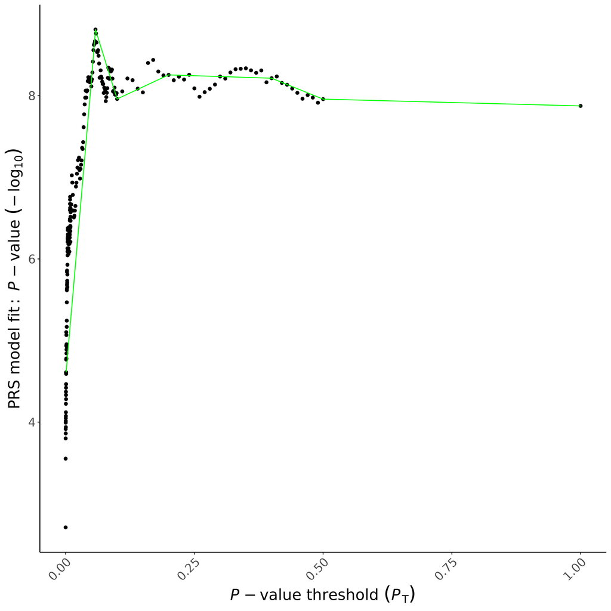

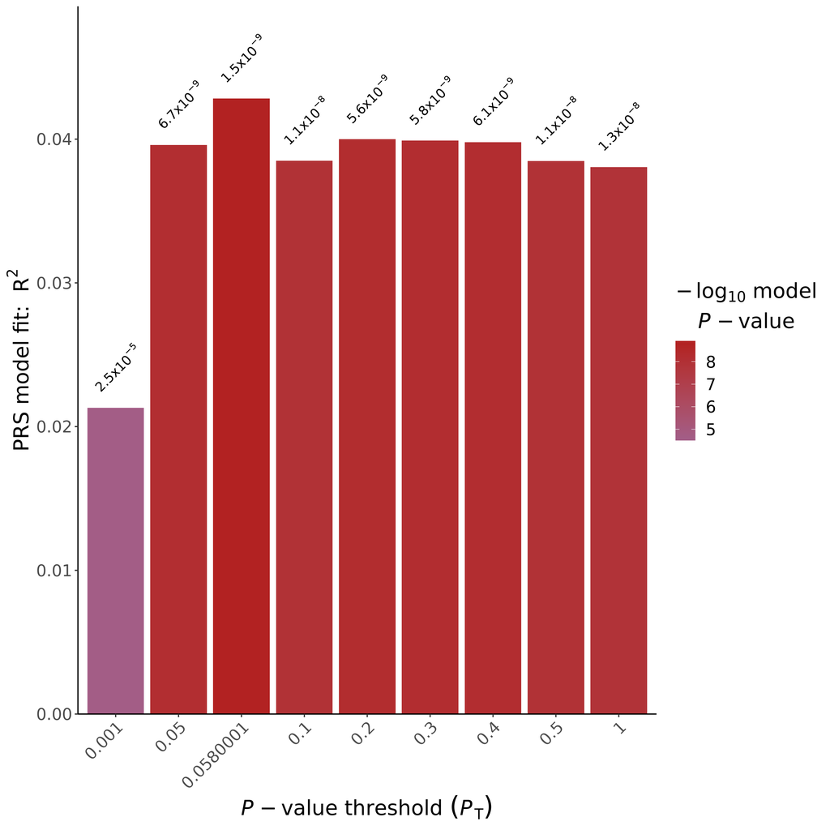

### LDpred Approach (python based)

1. Preprocess the base data file
2. Adjust effect size estimates
3. Calculate the PRS

```r
library(ggplot2)
p.threshold <- c(0.001,0.05,0.1,0.2,0.3,0.4,0.5)
phenotype <- read.table("EUR.height", header=T)
pcs <- read.table("EUR.eigenvec", header=F)
colnames(pcs) <- c("FID", "IID", paste0("PC",1:6))
covariate <- read.table("EUR.covariate", header=T)
pheno <- merge(merge(phenotype, covariate, by=c("FID", "IID")), pcs, by=c("FID","IID"))
null.r2 <- summary(lm(Height~., data=pheno[,!colnames(pheno)%in%c("FID","IID")]))$adj.r.squared
prs.result <- NULL
for(i in p.threshold){
    pheno.prs <- merge(pheno, read.table(paste0("./EUR.",i,".profile"), header=T)[,c("FID","IID", "SCORE")], by=c("FID", "IID"))
    model <- summary(lm(Height~., data=pheno.prs[,!colnames(pheno.prs)%in%c("FID","IID")]))
    model.r2 <- model$adj.r.squared
    prs.r2 <- model.r2-null.r2
    prs.coef <- model$coeff["SCORE",]
    prs.result <- rbind(prs.result,
        data.frame(Threshold=i, R2=prs.r2,
                    P=as.numeric(prs.coef[4]),
                    BETA=as.numeric(prs.coef[1]),
                    SE=as.numeric(prs.coef[2])))
}

print(prs.result)
```

```
##   Threshold         R2            P      BETA        SE
## 1     0.001 0.02033283 2.571442e-05  6914.685  1626.993
## 2     0.050 0.03870319 7.773190e-09 26097.905  4439.485
## 3     0.100 0.03790507 1.108123e-08 32850.602  5648.939
## 4     0.200 0.03943051 5.625333e-09 42742.820  7200.874
## 5     0.300 0.03932761 5.888796e-09 49241.288  8306.960
## 6     0.400 0.03922073 6.175493e-09 54595.311  9223.230
## 7     0.500 0.03789484 1.113169e-08 58479.355 10057.428
```

```r
# When p-value was chosen to be 0.2
i = 0.2
pheno.prs <- merge(pheno,
                        read.table(paste0("./EUR.",i,".profile"), header=T)[,c("FID","IID", "SCORE")],
                        by=c("FID", "IID"))
df = pheno.prs[,!colnames(pheno.prs)%in%c("FID","IID")]
model <- summary(lm(Height~., data=df))
model
```

```
##
## Call:
## lm(formula = Height ~ ., data = df)
##
## Residuals:
##     Min      1Q  Median      3Q     Max
## -9.5197 -2.2196 -0.0735  2.3001 11.2935
##
## Coefficients:
##               Estimate Std. Error t value Pr(>|t|)
## (Intercept)   161.0203     1.7302  93.064  < 2e-16 ***
## Sex            -4.0010     0.3044 -13.146  < 2e-16 ***
## PC1             0.8380     3.7577   0.223    0.824
## PC2             2.4877     7.5592   0.329    0.742
## PC3            -3.6505     3.4638  -1.054    0.292
## PC4             3.6949     3.3716   1.096    0.274
## PC5             2.3619     3.3328   0.709    0.479
## PC6             3.9339     3.3492   1.175    0.241
## SCORE       42742.8196  7200.8742   5.936 5.63e-09 ***
## ---
## Signif. codes:  0 '***' 0.001 '**' 0.01 '*' 0.05 '.' 0.1 ' ' 1
##
## Residual standard error: 3.332 on 478 degrees of freedom
## Multiple R-squared:  0.4574, Adjusted R-squared:  0.4483
## F-statistic: 50.36 on 8 and 478 DF,  p-value: < 2.2e-16
```

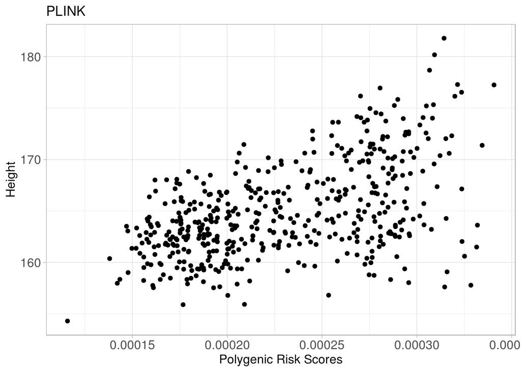

```r
ggplot(df, aes(x = SCORE, y = Height)) + geom_point() +
          labs(title = "PLINK",
               x = "Polygenic Risk Scores") + theme_light() +
          theme(axis.text.x = element_text(size = 12),
                axis.text.y = element_text(size = 12),
                axis.title=element_text(size = 12))
```

```r
prsiceScore<-read.table("./EUR.best", header = T)
samples <- intersect(phenotype$IID, prsiceScore$IID)
scores<-prsiceScore[prsiceScore$IID %in% samples,]
raw<-phenotype[phenotype$IID %in% samples,]
#check if the sample order is the same between phenotype and PRS data frame.
sum(as.character(scores$IID) == as.character(raw$IID)) # SAME
```

```
## [1] 487
```

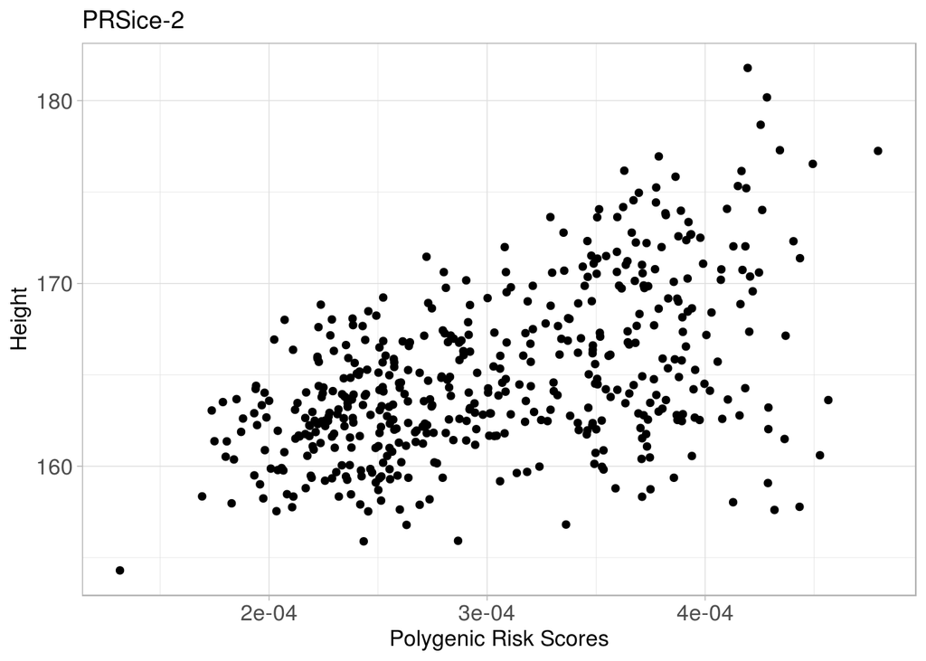

```r
df<-data.frame(raw, scores$PRS)
ggplot(df, aes(x = scores.PRS, y = Height)) + geom_point() +
          labs(title = "PRSice-2",
               x = "Polygenic Risk Scores") + theme_light() +
          theme(axis.text.x = element_text(size = 12),
                axis.text.y = element_text(size = 12),
                axis.title=element_text(size = 12))
```

```r
pheno.prs2 <- merge(pheno, prsiceScore[,c("FID","IID", "PRS")], by=c("FID", "IID"))
model<-lm(Height ~ ., data = pheno.prs2[,3:dim(pheno.prs)[2]])
summary(model)
```

```
##
## Call:
## lm(formula = Height ~ ., data = pheno.prs2[, 3:dim(pheno.prs)[2]])
##
## Residuals:
##    Min     1Q Median     3Q    Max
## -9.461 -2.150 -0.114  2.252 11.453
##
## Coefficients:
##               Estimate Std. Error t value Pr(>|t|)
## (Intercept)   162.2430     1.4829 109.408  < 2e-16 ***
## Sex            -3.9997     0.3036 -13.176  < 2e-16 ***
## PC1             0.7413     3.7292   0.199    0.843
## PC2             6.0901     6.8203   0.893    0.372
## PC3            -3.8684     3.4372  -1.125    0.261
## PC4             3.9410     3.3546   1.175    0.241
## PC5             2.2169     3.3245   0.667    0.505
## PC6             3.8644     3.3407   1.157    0.248
## PRS         28302.5717  4596.3501   6.158 1.57e-09 ***
## ---
## Signif. codes:  0 '***' 0.001 '**' 0.01 '*' 0.05 '.' 0.1 ' ' 1
##
## Residual standard error: 3.324 on 478 degrees of freedom
## Multiple R-squared:  0.4602, Adjusted R-squared:  0.4512
## F-statistic: 50.94 on 8 and 478 DF,  p-value: < 2.2e-16
```